# Tutoriel DADA2

Ce tutoriel présente la version 1.16 du pipeline DADA2, depuis les fichiers FASTQ démultiplexés jusqu'à la construction de tables ASV, l'attribution de taxonomie et l'importation dans phyloseq pour analyse.

## Préparation de l’environnement

On charge le package DADA2 et on vérifie la version

```r
library(dada2)
packageVersion("dada2")
```

```
[1] ‘1.28.0’
```

```r
# Charge le package DADA2 pour l'analyse de séquences amplicon
# Affiche ensuite la version du package utilisé
library(dada2); packageVersion("dada2")
```

```
[1] ‘1.28.0’
```

Les fichiers FASTQ d’exemple proviennent du protocole MiSeq SOP.

Ils ont été décompressés et stockés dans un dossier.

La variable `path` indique l’emplacement de ce dossier sur l’ordinateur.

```r
# Définit le chemin vers le dossier contenant les fichiers fastq après les avoir décompressés.
# Remplace "~/MiSeq_SOP" par le chemin réel sur ton ordinateur si nécessaire.
path <- "MiSeq_SOP"

# Liste tous les fichiers présents dans ce dossier pour vérifier que les fastq ont bien été trouvés# Liste tous les fichiers présents dans ce dossier pour vérifier que les fastq ont bien été trouvés
list.files(path)
```

```
 [1] "F3D0_S188_L001_R1_001.fastq"   "F3D0_S188_L001_R2_001.fastq"
 [3] "F3D1_S189_L001_R1_001.fastq"   "F3D1_S189_L001_R2_001.fastq"
 [5] "F3D141_S207_L001_R1_001.fastq" "F3D141_S207_L001_R2_001.fastq"
 [7] "F3D142_S208_L001_R1_001.fastq" "F3D142_S208_L001_R2_001.fastq"
 [9] "F3D143_S209_L001_R1_001.fastq" "F3D143_S209_L001_R2_001.fastq"
[11] "F3D144_S210_L001_R1_001.fastq" "F3D144_S210_L001_R2_001.fastq"
[13] "F3D145_S211_L001_R1_001.fastq" "F3D145_S211_L001_R2_001.fastq"
[15] "F3D146_S212_L001_R1_001.fastq" "F3D146_S212_L001_R2_001.fastq"
[17] "F3D147_S213_L001_R1_001.fastq" "F3D147_S213_L001_R2_001.fastq"
[19] "F3D148_S214_L001_R1_001.fastq" "F3D148_S214_L001_R2_001.fastq"
[21] "F3D149_S215_L001_R1_001.fastq" "F3D149_S215_L001_R2_001.fastq"
[23] "F3D150_S216_L001_R1_001.fastq" "F3D150_S216_L001_R2_001.fastq"
[25] "F3D2_S190_L001_R1_001.fastq"   "F3D2_S190_L001_R2_001.fastq"
[27] "F3D3_S191_L001_R1_001.fastq"   "F3D3_S191_L001_R2_001.fastq"
[29] "F3D5_S193_L001_R1_001.fastq"   "F3D5_S193_L001_R2_001.fastq"
[31] "F3D6_S194_L001_R1_001.fastq"   "F3D6_S194_L001_R2_001.fastq"
[33] "F3D7_S195_L001_R1_001.fastq"   "F3D7_S195_L001_R2_001.fastq"
[35] "F3D8_S196_L001_R1_001.fastq"   "F3D8_S196_L001_R2_001.fastq"
[37] "F3D9_S197_L001_R1_001.fastq"   "F3D9_S197_L001_R2_001.fastq"
[39] "filtered"                      "HMP_MOCK.v35.fasta"
[41] "Mock_S280_L001_R1_001.fastq"   "Mock_S280_L001_R2_001.fastq"
[43] "mouse.dpw.metadata"            "mouse.time.design"
[45] "stability.batch"               "stability.files"
```

Si le package DADA2 est chargé et que les fichiers FASTQ sont correctement listés, le pipeline peut commencer.

On lit ensuite les noms des fichiers FASTQ et on effectue quelques manipulations pour obtenir deux listes appariées : une pour les lectures forward et une pour les lectures reverse.

```r
# Forward and reverse fastq filenames have format: SAMPLENAME_R1_001.fastq and SAMPLENAME_R2_001.fastq

# Récupère et trie tous les fichiers fastq "forward" (_R1_001.fastq) dans le dossier path
# full.names = TRUE donne le chemin complet
fnFs <- sort(list.files(path, pattern="_R1_001.fastq", full.names = TRUE))

# Récupère et trie tous les fichiers fastq "reverse" (_R2_001.fastq) dans le dossier path
fnRs <- sort(list.files(path, pattern="_R2_001.fastq", full.names = TRUE))

# Extrait le nom de l'échantillon à partir du nom du fichier fastq forward
sample.names <- sapply(strsplit(basename(fnFs), "_"), `[`, 1)
```

## Inspection des profils de qualité de lecture

On commence par visualiser les profils de qualité des lectures forward (directes) afin de vérifier la qualité des séquences avant filtrage.

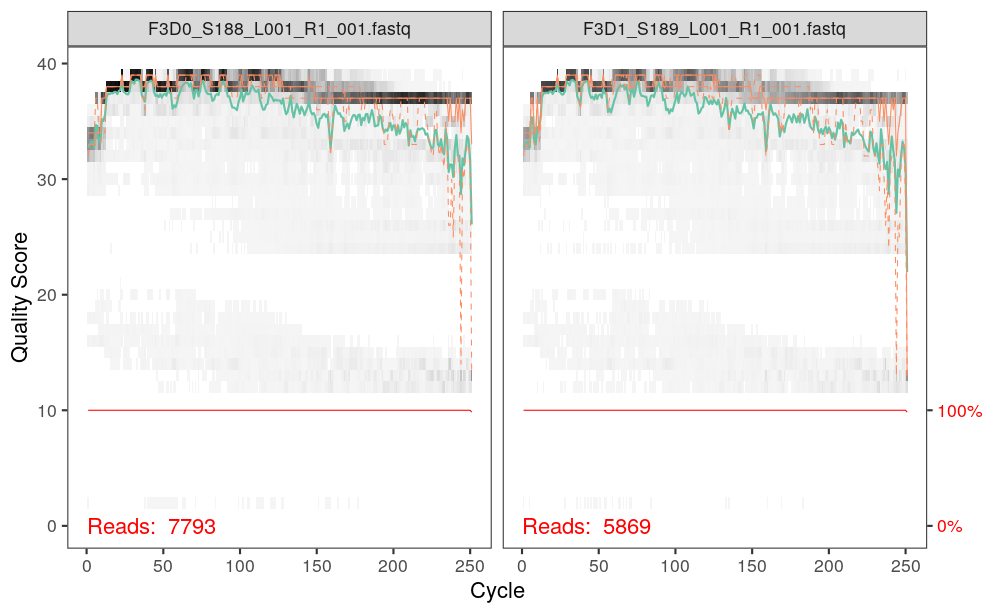

```r
# Affiche le profil de qualité des deux premiers fichiers forward
plotQualityProfile(fnFs[1:2])
```

La carte thermique montre la fréquence de chaque score de qualité à chaque position de base.

- La ligne verte indique le score de qualité moyen.
- Les lignes orange représentent les quartiles de la distribution des scores.
- La ligne rouge montre la proportion de lectures couvrant au moins cette position (utile surtout pour d’autres technologies, car les lectures Illumina ont généralement toutes la même longueur).

Les lectures forward sont de bonne qualité.

Il est recommandé de tronquer les derniers nucléotides pour éviter les erreurs, mais ces profils ne nécessitent pas de suppression supplémentaire.

On va donc tronquer les lectures directes à la position 240.

On passe maintenant à l’inspection des profils de qualité des lectures reverse (inverses) :

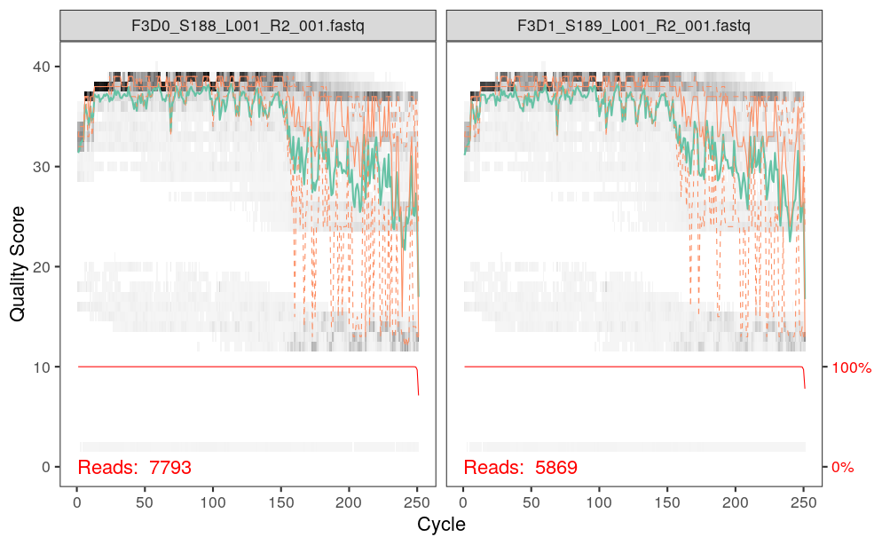

```r
# Affiche le profil de qualité des deux premiers fichiers reverse (_R2_001.fastq)
plotQualityProfile(fnRs[1:2])
```

Les lectures reverse ont une qualité inférieure, surtout vers la fin, ce qui est courant avec le séquençage Illumina.

DADA2 prend en compte la qualité des lectures dans son modèle d’erreurs, ce qui rend l’algorithme robuste aux séquences moins bonnes.

Cependant, tronquer les lectures là où la qualité moyenne chute améliore la détection des variants rares.

Sur cette base, les lectures inverses seront tronquées à la position 160, là où la qualité diminue fortement.

## Filtrer et découper

On crée des noms pour les fichiers FASTQ filtrés afin de les stocker après le filtrage et le tronquage.

Chaque échantillon aura un fichier pour les lectures forward et un fichier pour les lectures reverse.

```r
# Place filtered files in filtered/ subdirectory
# Crée les chemins complets pour les fichiers forward filtrés
filtFs <- file.path(path, "filtered", paste0(sample.names, "_F_filt.fastq.gz"))

# Crée les chemins complets pour les fichiers reverse filtrés
filtRs <- file.path(path, "filtered", paste0(sample.names, "_R_filt.fastq.gz"))

# Associe les noms des échantillons aux vecteurs de fichiers filtrés
names(filtFs) <- sample.names
names(filtRs) <- sample.names
```

On applique les paramètres de filtrage standard de DADA2 pour limiter les erreurs et supprimer les bases ambiguës et contaminations.

```r
# Filtre et tronque les reads forward et reverse selon leur qualité et supprime les reads PhiX, puis affiche un aperçu du nombre de reads retenus
out <- filterAndTrim(fnFs, filtFs, fnRs, filtRs, truncLen=c(240,160),
              maxN=0, maxEE=c(2,2), truncQ=2, rm.phix=TRUE,
              compress=TRUE, multithread=TRUE) # On Windows set multithread=FALSE
head(out)
```

```
                              reads.in reads.out
F3D0_S188_L001_R1_001.fastq       7793      7113
F3D1_S189_L001_R1_001.fastq       5869      5299
F3D141_S207_L001_R1_001.fastq     5958      5463
F3D142_S208_L001_R1_001.fastq     3183      2914
F3D143_S209_L001_R1_001.fastq     3178      2941
F3D144_S210_L001_R1_001.fastq     4827      4312
```

## Apprentissage des taux d’erreur

DADA2 apprend un modèle d’erreurs spécifique à chaque jeu de données en estimant les taux d’erreur et la composition des échantillons jusqu’à obtenir une solution cohérente.

Il est utile de visualiser les taux d’erreur estimés pour vérifier la cohérence des résultats.

```r
# Affiche le profil des erreurs estimées pour les reads forward afin de visualiser la qualité du modèle d'erreurs
plotErrors(errF, nominalQ=TRUE)
```

[output not shown]

## Inférence d’échantillon

Les donnée filtrées et tronquées sont maintenant prêtes pour l’inférence des séquences exactes par l’algorithme DADA2.

```r
# Applique l'algorithme DADA aux reads forward filtrés pour corriger les erreurs et identifier les vraies séquences
dadaFs <- dada(filtFs, err=errF, multithread=TRUE)
```

```r
# Applique l'algorithme DADA aux reads reverse filtrés pour corriger les erreurs et identifier les vraies séquences
dadaRs <- dada(filtRs, err=errR, multithread=TRUE)
```

On inspecte maintenant l’objet renvoyé par l’algorithme DADA2 pour vérifier les résultats et comprendre sa structure.

```r
# Affiche le détail des séquences denoised et de leur abondance pour le premier échantillon forward
dadaFs[[1]]
```

L’objet renvoyé contient de nombreuses informations détaillées sur chaque variant, mais seul un aperçu est présenté ici.

## Fusion des lectures appariées

L’objet renvoyé contient de nombreuses informations détaillées sur chaque variant, mais seul un aperçu est présenté ici.

```r
# Fusionne les reads forward et reverse denoised pour reconstruire les séquences complètes d'ADN
mergers <- mergePairs(dadaFs, filtFs, dadaRs, filtRs, verbose=TRUE)
```

```
6540 paired-reads (in 107 unique pairings) successfully merged out of 6891 (in 197 pairings) input.
5028 paired-reads (in 101 unique pairings) successfully merged out of 5190 (in 157 pairings) input.
4986 paired-reads (in 81 unique pairings) successfully merged out of 5267 (in 166 pairings) input.
2595 paired-reads (in 52 unique pairings) successfully merged out of 2754 (in 108 pairings) input.
2553 paired-reads (in 60 unique pairings) successfully merged out of 2785 (in 119 pairings) input.
3646 paired-reads (in 55 unique pairings) successfully merged out of 4109 (in 157 pairings) input.
6079 paired-reads (in 81 unique pairings) successfully merged out of 6514 (in 198 pairings) input.
3968 paired-reads (in 91 unique pairings) successfully merged out of 4388 (in 187 pairings) input.
14233 paired-reads (in 143 unique pairings) successfully merged out of 15355 (in 352 pairings) input.
10528 paired-reads (in 120 unique pairings) successfully merged out of 11165 (in 278 pairings) input.
11154 paired-reads (in 137 unique pairings) successfully merged out of 11797 (in 298 pairings) input.
4349 paired-reads (in 85 unique pairings) successfully merged out of 4802 (in 179 pairings) input.
17431 paired-reads (in 153 unique pairings) successfully merged out of 17812 (in 272 pairings) input.
5850 paired-reads (in 81 unique pairings) successfully merged out of 6095 (in 159 pairings) input.
3716 paired-reads (in 86 unique pairings) successfully merged out of 3894 (in 147 pairings) input.
6865 paired-reads (in 99 unique pairings) successfully merged out of 7191 (in 187 pairings) input.
4426 paired-reads (in 67 unique pairings) successfully merged out of 4603 (in 127 pairings) input.
4576 paired-reads (in 101 unique pairings) successfully merged out of 4739 (in 174 pairings) input.
6092 paired-reads (in 109 unique pairings) successfully merged out of 6315 (in 173 pairings) input.
4269 paired-reads (in 20 unique pairings) successfully merged out of 4281 (in 28 pairings) input.
```

```r
# Affiche les premières lignes du tableau de fusion pour le premier échantillon afin de vérifier la fusion
head(mergers[[1]])
```

|  | sequence | abundance | forward | reverse | nmatch | nmismatch | nindel | prefer | accept |
| --- | --- | --- | --- | --- | --- | --- | --- | --- | --- |
| 1 | TACGGAGGATGCGAGCGTTATCCGGATTTATTGGGTTTAAAGGGTGCGCAGGCGGAAGAT…… | 579 | 1 | 1 | 148 | 0 | 0 | 1 | TRUE |
| 2 | TACGGAGGATGCGAGCGTTATCCGGATTTATTGGGTTTAAAGGGTGCGTAGGCGGCCTGC…… | 470 | 2 | 2 | 148 | 0 | 0 | 2 | TRUE |
| 3 | TACGGAGGATGCGAGCGTTATCCGGATTTATTGGGTTTAAAGGGTGCGTAGGCGGGCTGT…… | 449 | 3 | 4 | 148 | 0 | 0 | 1 | TRUE |
| 4 | TACGGAGGATGCGAGCGTTATCCGGATTTATTGGGTTTAAAGGGTGCGTAGGCGGGCTTT…… | 430 | 4 | 3 | 148 | 0 | 0 | 2 | TRUE |
| 5 | TACGGAGGATGCGAGCGTTATCCGGATTTATTGGGTTTAAAGGGTGCGCAGGCGGACTCT…… | 345 | 5 | 6 | 148 | 0 | 0 | 1 | TRUE |
| 6 | TACGGAGGATGCGAGCGTTATCCGGATTTATTGGGTTTAAAGGGTGCGTAGGCGGGATGC…… | 282 | 6 | 5 | 148 | 0 | 0 | 2 | TRUE |

L’objet `mergers` est une liste de data.frames, un par échantillon.

Chaque data.frame contient la séquence fusionnée (`$sequence`), son abondance (`$abundance`) et les indices des variants forward et reverse qui ont été fusionnés.

Les lectures appariées qui ne se chevauchaient pas exactement ont été supprimées par `mergePairs`, ce qui réduit encore les séquences parasites.

## Construction d’une table de séquence

On construit maintenant une table de variants de séquences d’amplicons (ASV), une version plus précise que la table OTU traditionnelle.

```r
# Construit la table de séquences (ASV table) : lignes = échantillons, colonnes = séquences uniques
seqtab <- makeSequenceTable(mergers)

# Affiche les dimensions de la table (nombre d'échantillons × nombre de séquences uniques)
dim(seqtab)
```

```r
# Vérifie la distribution des longueurs des séquences dans la table ASV
table(nchar(getSequences(seqtab)))
```

```
251 252 253 254 255
  1  88 196   6   2
```

La table de séquences est une matrice avec des lignes pour chaque échantillon et des colonnes pour chaque variant de séquence.

Elle contient 293 ASV, et les longueurs des séquences fusionnées sont toutes dans la plage attendue pour l’amplicon V4.

## Suppresssion des chimères

La méthode principale de DADA2 corrige les erreurs de substitution et d’insertion/délétion, mais certaines chimères restent présentes.

Les ASV débruités facilitent leur identification : une séquence est considérée chimérique si elle peut être reconstruite en combinant exactement des segments gauche et droit provenant de deux séquences parentales plus abondantes.

```r
# Supprime les séquences chimériques (artefacts formés par recombinaison de séquences abondantes)
seqtab.nochim <- removeBimeraDenovo(seqtab, method="consensus", multithread=TRUE, verbose=TRUE)

# Affiche les dimensions de la table après suppression des chimères (échantillons × séquences uniques restantes)
dim(seqtab.nochim)
```

```r
# Calcule la proportion de reads conservés après suppression des chimères
sum(seqtab.nochim)/sum(seqtab)
```

La proportion de séquences chimériques varie selon les jeux de données et dépend de facteurs expérimentaux et de la complexité des échantillons.

## Suivi des lectures tout au long du pipeline

Pour vérifier l’avancement du pipeline, on examine le nombre de lectures conservées à chaque étape du processus.

```r
# Crée un tableau récapitulatif montrant le nombre de reads conservés à chaque étape du pipeline pour chaque échantillon
getN <- function(x) sum(getUniques(x))
track <- cbind(out, sapply(dadaFs, getN), sapply(dadaRs, getN), sapply(mergers, getN), rowSums(seqtab.nochim))
# If processing a single sample, remove the sapply calls: e.g. replace sapply(dadaFs, getN) with getN(dadaFs)
colnames(track) <- c("input", "filtered", "denoisedF", "denoisedR", "merged", "nonchim")
rownames(track) <- sample.names
head(track)
```

## Attribution d’une taxonomie

Il est courant d’attribuer une taxonomie aux variants de séquence, par exemple pour le séquençage 16S, 18S ou ITS.

DADA2 propose une méthode de classification bayésienne naïve via la fonction `assignTaxonomy`, qui utilise des séquences de référence pour assigner une taxonomie à chaque variant avec un niveau de confiance minimal (`minBoot`).

```r
# Assigne un taxon à chaque séquence non chimérique en comparant aux séquences de référence SILVA
taxa <- assignTaxonomy(seqtab.nochim, "~/silva_nr_v132_train_set.fa.gz", multithread=TRUE)
```

On vérifie maintenant les classifications taxonomiques attribuées à nos variants de séquence.

```r
# Prépare une version du tableau taxonomique sans les noms de séquences pour un affichage plus lisible
taxa.print <- taxa # Removing sequence rownames for display only
rownames(taxa.print) <- NULL

# Affiche les premières lignes du tableau pour vérifier l’assignation taxonomique
head(taxa.print)
```

## Evaluation de la précision

Un des échantillons est une « communauté simulée » contenant un mélange de souches connues.

On compare les variants de séquence identifiés par DADA2 à la composition attendue pour évaluer la précision de l’algorithme sur cet échantillon.

```r
# Analyse des séquences présentes dans l'échantillon témoin "Mock" :
# Trie les ASV détectées par abondance et affiche combien de séquences DADA2 a identifiées dans le Mock
unqs.mock <- seqtab.nochim["Mock",]
unqs.mock <- sort(unqs.mock[unqs.mock>0], decreasing=TRUE) # Drop ASVs absent in the Mock
cat("DADA2 inferred", length(unqs.mock), "sample sequences present in the Mock community.\n")
```

```r
# Analyse des séquences présentes dans l'échantillon témoin "Mock" :
# Trie les ASV détectées par abondance et affiche combien de séquences DADA2 a identifiées dans le Mock
mock.ref <- getSequences(file.path(path, "HMP_MOCK.v35.fasta"))
match.ref <- sum(sapply(names(unqs.mock), function(x) any(grepl(x, mock.ref))))
cat("Of those,", sum(match.ref), "were exact matches to the expected reference sequences.\n")
```

**La partie DADA2 du tutoriel se termine ici.**

## Bonus : Passage à phyloseq

Le package R **phyloseq** permet une analyse approfondie des données de microbiome.

On montre ici comment importer les tableaux produits par DADA2 et ajouter les métadonnées disponibles, comme le sexe, le numéro de l’individu et le jour post-sevrage des prélèvements (par exemple, GXDY).

```r
# Charge le package phyloseq pour l'analyse et la visualisation des données microbiomes et affiche sa version
library(phyloseq); packageVersion("phyloseq")
```

```r
# Charge le package Biostrings pour manipuler les séquences ADN/ARN en R et affiche sa version
library(Biostrings); packageVersion("Biostrings")
```

```r
# Charge le package ggplot2 pour créer des graphiques et visualisations, et affiche sa version
library(ggplot2); packageVersion("ggplot2")
```

```r
# Définit le thème par défaut des graphiques ggplot2 sur un fond blanc avec grille (theme_bw)
theme_set(theme_bw())
```

On peut créer un `data.frame` d’échantillons à partir des informations contenues dans les noms de fichiers.

Dans un cas réel, ces métadonnées seraient généralement lues depuis un fichier séparé.

```r
# Crée un tableau de métadonnées pour les échantillons à partir des noms de fichiers :
# - extrait le sujet, le sexe et le jour de l'échantillon
# - ajoute une colonne "When" indiquant Early (jour ≤100) ou Late (jour >100)
# - définit les noms des lignes du tableau selon les noms des échantillons
samples.out <- rownames(seqtab.nochim)
subject <- sapply(strsplit(samples.out, "D"), `[`, 1)
gender <- substr(subject,1,1)
subject <- substr(subject,2,999)
day <- as.integer(sapply(strsplit(samples.out, "D"), `[`, 2))
samdf <- data.frame(Subject=subject, Gender=gender, Day=day)
samdf$When <- "Early"
samdf$When[samdf$Day>100] <- "Late"
rownames(samdf) <- samples.out
```

On crée maintenant un objet **phyloseq** en utilisant directement les tables et résultats produits par DADA2.

```r
# Crée un objet phyloseq combinant la table ASV, les métadonnées et les informations taxonomiques,
# puis supprime l'échantillon témoin "Mock" pour les analyses downstream
ps <- phyloseq(otu_table(seqtab.nochim, taxa_are_rows=FALSE),
               sample_data(samdf),
               tax_table(taxa))
ps <- prune_samples(sample_names(ps) != "Mock", ps) # Remove mock sample
```

Pour faciliter l’utilisation dans phyloseq, on attribue des noms courts aux ASV (par exemple ASV1, ASV2) plutôt que d’utiliser les séquences complètes.

Les séquences d’ADN complètes sont conservées dans l’emplacement `refseq` de l’objet phyloseq, ce qui permet de les utiliser ultérieurement tout en affichant des noms courts dans les tableaux et graphiques.

```r
# Crée un objet DNAStringSet avec les séquences des ASV, l'ajoute à l'objet phyloseq,
# puis renomme les ASV de manière uniforme (ASV1, ASV2, ...) pour simplifier les références
dna <- Biostrings::DNAStringSet(taxa_names(ps))
names(dna) <- taxa_names(ps)
ps <- merge_phyloseq(ps, dna)
taxa_names(ps) <- paste0("ASV", seq(ntaxa(ps)))
ps
```

Les données sont maintenant prêtes à être analysées avec **phyloseq**.

On commence par visualiser l’**alpha-diversité**, qui mesure la diversité au sein de chaque échantillon.

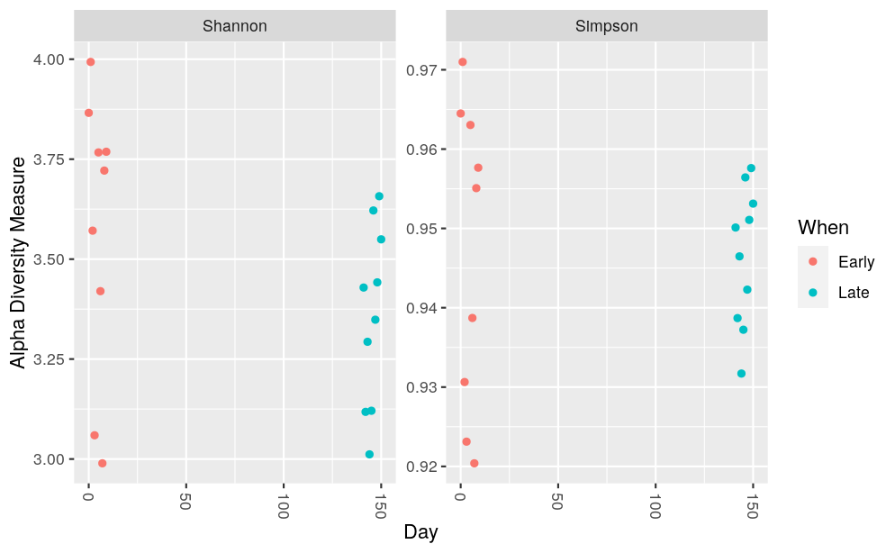

```r
# Trace la diversité alpha (indices de Shannon et Simpson) des échantillons en fonction du jour,
# en colorant selon la période "Early" ou "Late"
plot_richness(ps, x="Day", measures=c("Shannon", "Simpson"), color="When")
```

Il n’y a pas de différence systématique notable dans la diversité alpha entre les échantillons précoces et tardifs.

On passe maintenant à l’**ordination**, qui permet de visualiser les similarités et différences globales entre les échantillons.

```r
# Transforme les comptes d'ASV en proportions pour chaque échantillon et calcule un ordonnancement NMDS
# basé sur la distance de Bray-Curtis pour visualiser les différences communautaires entre échantillons
ps.prop <- transform_sample_counts(ps, function(otu) otu/sum(otu))
ord.nmds.bray <- ordinate(ps.prop, method="NMDS", distance="bray")
```

```
*** Best solution repeated 1 times
```

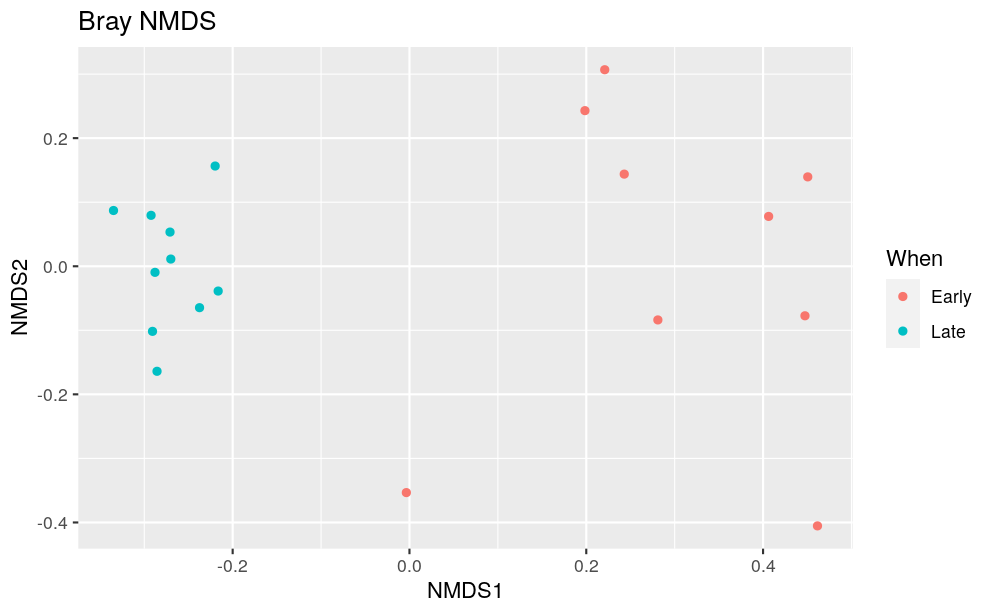

```r
# Affiche l'ordonnancement NMDS basé sur la distance de Bray-Curtis en colorant les échantillons selon "When"
plot_ordination(ps.prop, ord.nmds.bray, color="When", title="Bray NMDS")
```

L’ordination montre une séparation claire entre les échantillons précoces et tardifs.

On peut maintenant visualiser la composition taxonomique des échantillons à l’aide d’un **diagramme à barres**.

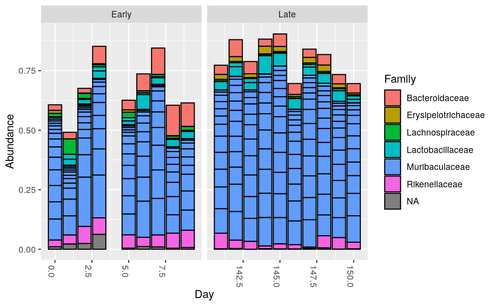

```r
# Sélectionne les 20 ASV les plus abondantes dans tout l'objet phyloseq
top20 <- names(sort(taxa_sums(ps), decreasing=TRUE))[1:20]

# Transforme les comptes d'ASV en proportions pour chaque échantillon
ps.top20 <- transform_sample_counts(ps, function(OTU) OTU/sum(OTU))

# Garde uniquement les 20 ASV les plus abondantes, supprime les autres
ps.top20 <- prune_taxa(top20, ps.top20)

# Crée un diagramme en barres montrant la composition relative des ASV par jour
# Les barres sont colorées selon la famille taxonomique
# Sépare les graphiques selon les périodes "Early" et "Late"
plot_bar(ps.top20, x="Day", fill="Family") + facet_wrap(~When, scales="free_x")
```

La distribution des 20 principaux taxons ne montre pas d’explication évidente à la séparation entre échantillons précoces et tardifs.

Ces exemples illustrent simplement comment importer les résultats de DADA2 dans phyloseq et réaliser quelques analyses de base.

Pour explorer toutes les possibilités offertes par phyloseq, consultez la documentation officielle : [**https://joey711.github.io/phyloseq/**](https://joey711.github.io/phyloseq/)**.**